# Pre & Post Tests

Hunter Ratliff, @HunterRatliff1

August 1, 2016

**Author:** @HunterRatliff1  
**Published to:** `NA`  
**Source Code:** Available on [Github](https://github.com/HunterRatliff1/)

- Repo: HunterRatliff1/HSSC2016
- File: [~/HSSC2016/HS/TestResults.Rmd](https://github.com/HunterRatliff1/HSSC2016/blob/master/HS/TestResults.Rmd)

# Objectives

Taken from the *Summer STEM Grant to Dell Med School Reporting Matrix*

## In this report

**Objective #1:** Increase students’ interest in health careers as measured by post-survey  
**Objective #2:** Improve students’ focus and interest in school  
**Objective #3:** Improve students’ enrollment in STEM courses at their school  
**Objective #4:** Improve the academic credentials of students applying to college  
**Objective #5:** Increase middle and high-school students’ (especially minority and disadvantaged sudents’) science knowledge and preparedness for health professions

|  | Historical | Projected |
| --- | --- | --- |
| #1 | 80% of students surveyed indicated that they were more likely to pursue a health science career after completing the camp | **80%** of students surveyed will indicate **greater likelihood** of **pursuing a health science career *after*** completing the camp |
| #2 | `Not measured` | In post-camp survey, **85%** of students will indicate their **understanding of the need to focus and do well in school** |
| #3 | In 2015, 85% of campers stated that they learned the importance of math and science in the real world by attending the camp | In post-camp survey, **85%** of students will indicate their **intention to enroll in STEM courses** at their school† |
| #4 | `Not measured` | Through content-rich questions on pre and post-tests, **85%** of students will **demonstrate knowedge gained** - thus improved academic readiness |
| #5 | `Not measured` | Through content-rich questions on pre and post-tests, **85%** of students will demonstrate **increased science knowledge** and **preparedness** for health professions |

† Can further assess this goal at the end of each subsequent academic year by tracking students’ choices and performance in STEM courses

## Not measured here

**Objective #1:** Identify promising students and foster their further development†  
**Objective #2:** Number of students participating in summer program (number of students registered & number of students completing)  
**Objective #3:** Dosage and duration of program  
**Objective #4:** Program continuation/attendance during the following school year

|  | Historical | Projected |
| --- | --- | --- |
| #1 | In 2015, 100 promising students were identified by their school counselors and instructed/ encouraged by program leadership and summer camp counselors | In 2016, 200 promising students will be identified by their school counselors and instructed/encouraged by program leadership and summer camp counselors‡ |
| #2 | A total of 100 students enrolled in the 2015 summer camp: 50 high-school-age, 50 middle-school-age. All completed the program | Number of students participating in the camp will double to 200: 100 high-school level, 100 middle-school level. Goal is that 90% will complete the summer program |
| #3 | In 2015, camps were 8 hours/day, 5 days a week. Two one-week sessions were held | Two one-week sessions will be held: one for middle school, one for high school. Each camp will be 8 hours/day, 5 days/week |
| #4 | `School year sessions were not held` | 50%-75% of participants will extend their involvement through planned (weekend) activities during academic year 2016-17‡ |

† Can assess ongoing development of students by monitoring their continued participation in the program and sustained interest and performance in STEM ‡ New element (not measurable within the summer time frame) is that 50%-75% of participants will extend their involvement through planned activities during academic year 2016-17.

# High Level Visualizations

First, let’s compare the distributions of the pre-tests and post-tests. Later, we can dive into the weeds by looking at the questions and individual camper’s imporvements, but to begin we’ll consider the aggregate distribution of scores:

## Before the camp

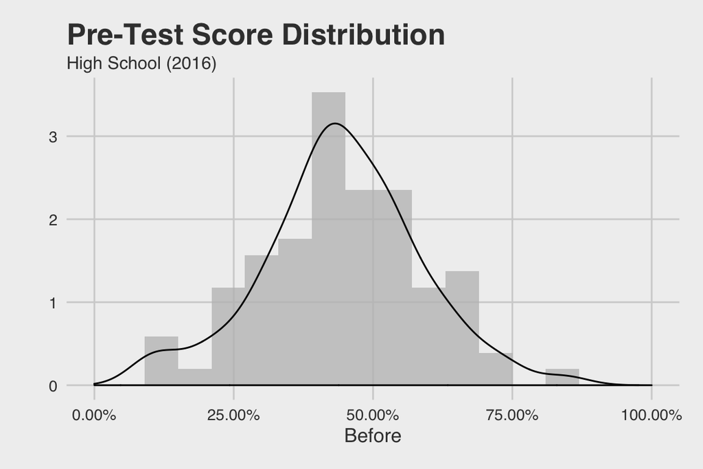

Figure 1A

## After the camp

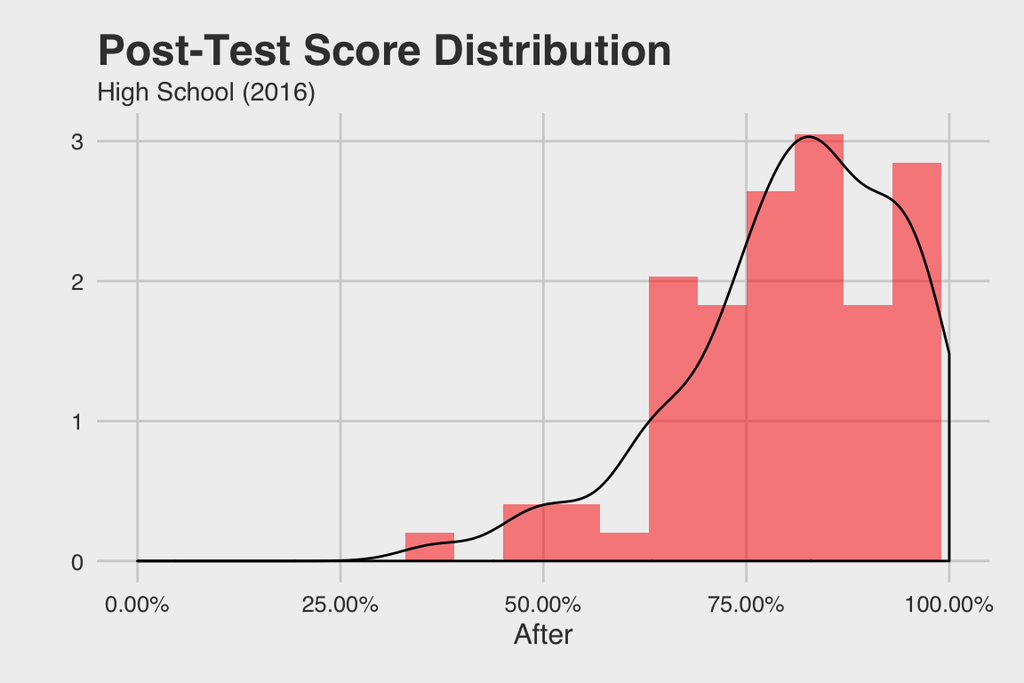

Figure 1B

| Type | mean | median | sd |
| --- | --- | --- | --- |
| After | 80.87 | 84.21 | 13.63 |
| Before | 44.24 | 42.11 | 14.24 |

# Hypothesis testing

```r
# Run a paired Student's T-test (one-sided)
t.test(Dems$After, Dems$Before, alternative = "greater", paired=T)
```

```
##
##  Paired t-test
##
## data:  Dems$After and Dems$Before
## t = 24.033, df = 65, p-value < 2.2e-16
## alternative hypothesis: true difference in means is greater than 0
## 95 percent confidence interval:
##  0.3472939       Inf
## sample estimates:
## mean of the differences
##               0.3732057
```

```r
# Determine effect size (Cohen's d)
cohen.d(Dems$After, Dems$Before, paired=T, na.rm=T)
```

```
##
## Cohen's d
##
## d estimate: 2.958283 (large)
## 95 percent confidence interval:
##      inf      sup
## 2.454101 3.462465
```

# Pre-Test Questions

[interactive chart not shown]

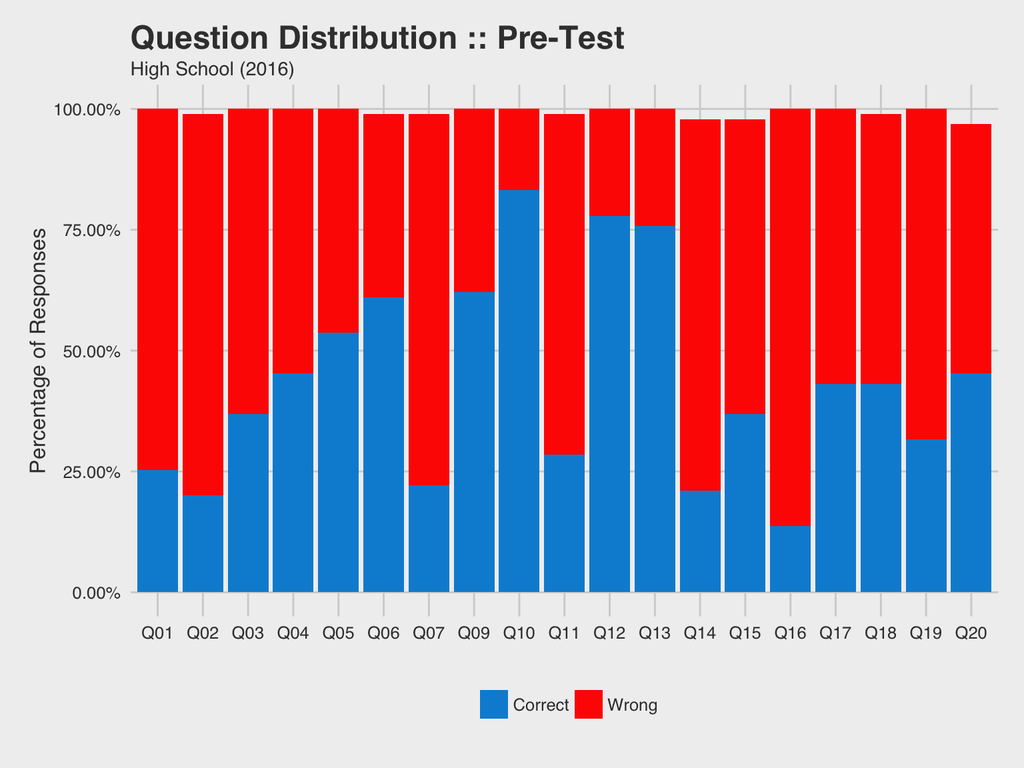

Figure 2A

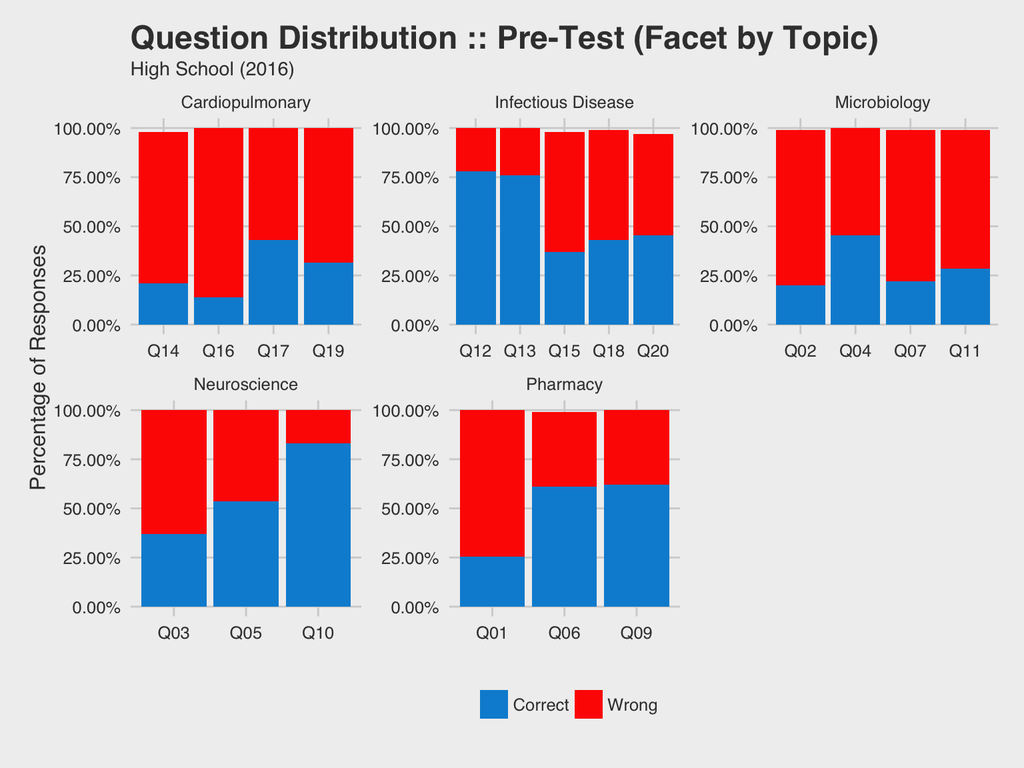

Figure 2B

# Pre & Post Test Scores

Among our Short-term Outcomes **Objective:** Through content-rich questions on pre-and post-tests, 85% of students will demonstrate knowedge gained - thus improved academic readiness. **Objective:** Through content-rich questions on pre-and post-tests, 85% of students will demonstrate increased science knowledge and preparedness for health professions.

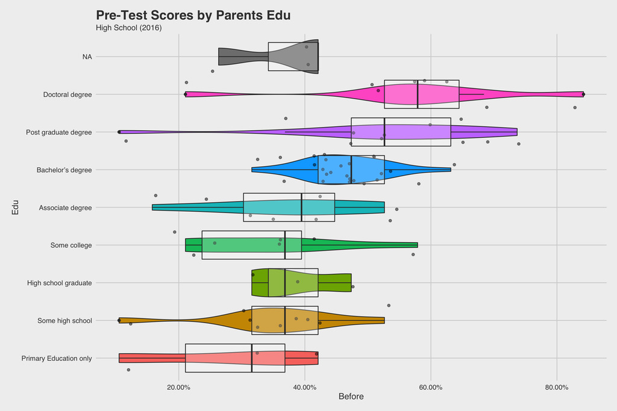

Figure 9

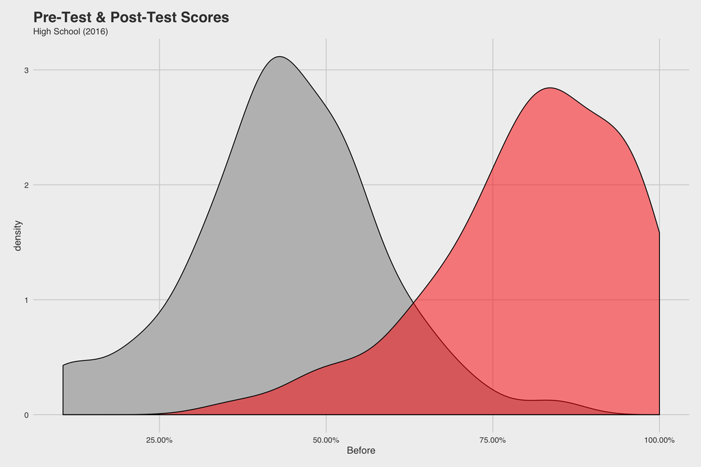

Figure 10A

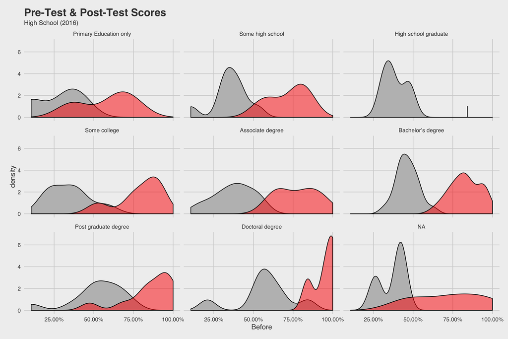

Figure 10B

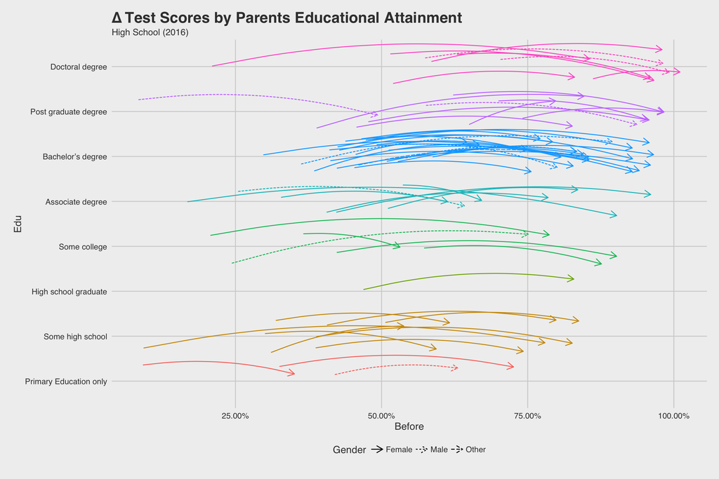

Figure 11a

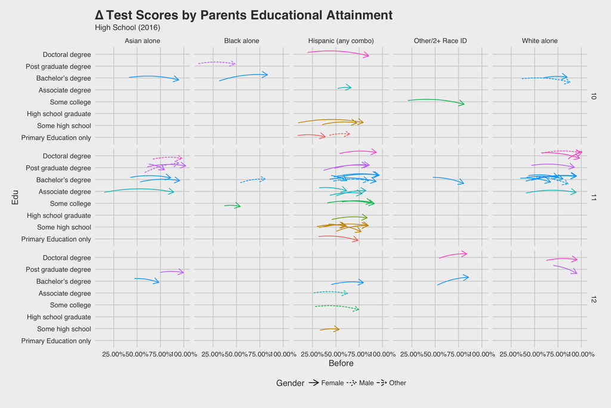

Figure 11B